# week4_lab

# Week 4 Lab: Introduction to Data Visualization

## September 24, 2020

This lab reviews some of the basics of visualizing data in R. You will work with ggplot to great several kinds of figures that display the relationship between variables.

### Required packages:

Please load tidyverse and GGall (you might need to also insall GGally if you haven’t already):

```r
library(tidyverse)
library(GGally)
```

### Data

Download the data files from canvas. These are slighly modified data sets from this Five Thirty Eight article: https://projects.fivethirtyeight.com/next-bechdel/. You can also find out more about the Bechdel test here: https://bechdeltest.com/ (including results for more recent movies!)

You need the following data files:

**all_tests** : The top 50 movies in 2016 with a column for each proposed “next” bechdel test (a simple measure of gender imbalance in films). 0 = failed the test. 1= passed the test. You can read about each test in the Five Thirty Eight article linked above.

**cast:** The number of roles, per film, played by men, women, and other (either gender unknown or person is outside the gender binary)

To read the code as written set your working directory to be whatever folder holds the next-bechdel folder you download from canvas. We recommend starting a R-Project for this class (do so via File>New Project or in the top right corner).Then just drag the next-bechdel folder into the folder the R-Project is in. You can also set your working directory by going to Session > Set Working Directory > Choose Directory.

```r
all_tests<-read.csv("next-bechdel/alltests.csv")
cast<-read.csv("next-bechdel/cast.csv")
```

## Scatterplot

### Comparing two variables: Proportion of Women acting in a film X number of passed tests

Our variables of interest are currently in two different dataframes so we’ll need to make a new dataframe that we can then plot. We also need to calculate the number of passed tests from all_tests and the proportion of women from the counts provided.

```r
# make new variable for passed tests
# remember mutate allows us to make a new variable
all_tests <- all_tests %>%
  mutate(total_pass= rowSums(.[2:14])) # call the rows we want to sum in the []s. rowSums sums across rows...

# isolate number of women in the cast for each movie & make proportion of total roles

cast_w<- cast %>%
  group_by(MOVIE)%>%
  filter(gender=="Women") %>%
  mutate(w_prop=gender_count/roles) %>%
  rename(movie="MOVIE") # rename movie so that the two datasets match

# join together our two new datasets

pass_women_count <- left_join(all_tests, cast_w, by="movie")
```

Now we have dataset that we can use to make a scatterplot: ggplot works with the following structure: ggplot(data, aes(x=variable on x axis, y= variable on y axis))+ geom_XXXX()

We’ll see a number of different geoms throughout the lab, but there are many more! Here’s a good cheat sheet with many of the options: https://rstudio.com/wp-content/uploads/2015/03/ggplot2-cheatsheet.pdf

You can also call the aes in either the top ggplot() or within the geom(). AS well as adding many other features (like color, fill, shape, etc).

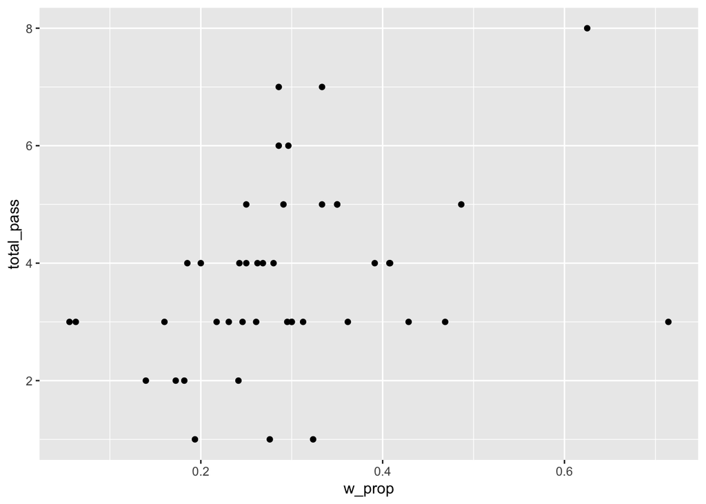

```r
ggplot(pass_women_count, aes(x=w_prop, y=total_pass))+
  geom_point()
```

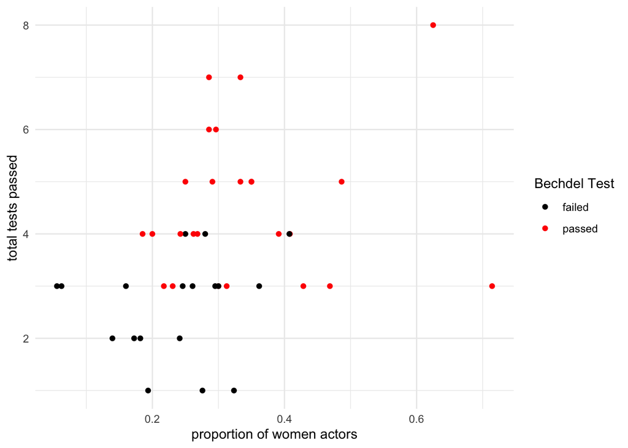

```r
## making a nicer graph
ggplot(pass_women_count, aes())+
  geom_point(aes(x=w_prop, y=total_pass,color=as.character(bechdel)))+
  scale_color_manual(values=c("black", "red"),
                   labels=c("failed", "passed"),
                   name="Bechdel Test")+
  theme_minimal()+
  labs(y="total tests passed", x="proportion of women actors")
```

## Histogram

### number of movies that pass x tests

Histograms are great ways to see how a variable is distributed among your data. Here we make one to see how the number of passed tests falls across our groups of films.

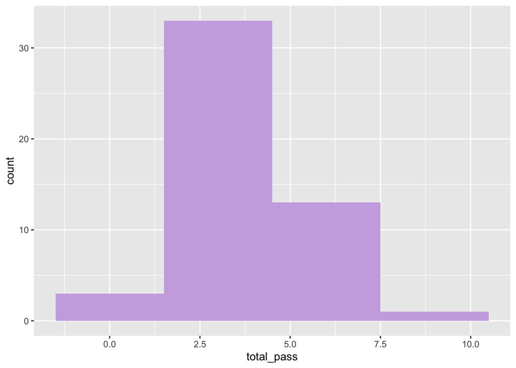

```r
ggplot(all_tests, aes(x=total_pass))+
  geom_histogram(binwidth=3, fill="#ccaee2") ## what happens when we change the binwidth?
```

## Correlation Plot

### Compare how a number of variables correlate with one another.

Here we’ll see how the number of men, number of women, and number of passed tests are correlated.

```r
counts<- cast %>%
  group_by(MOVIE) %>%
  spread(gender, gender_count)%>% # spread is extremely handy! It takes what's in rows and makes them into columns
  rename(movie="MOVIE")

# to see what spread does compare counts and cast
counts
```

```
## # A tibble: 50 x 5
## # Groups:   movie [50]
##    movie                              roles   Men Other Women
##    <fct>                              <int> <int> <int> <int>
##  1 10 Cloverfield Lane                   10     5     2     3
##  2 Alice Through the Looking Glass       23    11     3     9
##  3 Arrival                               60    30     9    21
##  4 Bad Moms                              16     4     2    10
##  5 Batman v Superman: Dawn of Justice   122    78     8    36
##  6 Captain America: Civil War            26    15     5     6
##  7 Central Intelligence                  25    17     4     4
##  8 Deadpool                              34    18     5    11
##  9 Doctor Strange                        29    16     5     8
## 10 Don’t Breathe                         10     5    NA     5
## # … with 40 more rows
```

```r
cast
```

```
##                                                MOVIE roles gender gender_count
## 1                                10 Cloverfield Lane    10    Men            5
## 2                                10 Cloverfield Lane    10  Other            2
## 3                                10 Cloverfield Lane    10  Women            3
## 4                    Alice Through the Looking Glass    23    Men           11
## 5                    Alice Through the Looking Glass    23  Other            3
## 6                    Alice Through the Looking Glass    23  Women            9
## 7                                            Arrival    60    Men           30
## 8                                            Arrival    60  Other            9
## 9                                            Arrival    60  Women           21
## 10                                          Bad Moms    16    Men            4
## 11                                          Bad Moms    16  Other            2
## 12                                          Bad Moms    16  Women           10
## 13                Batman v Superman: Dawn of Justice   122    Men           78
## 14                Batman v Superman: Dawn of Justice   122  Other            8
```

[output cut: 133 more lines]

```r
passed_tests <- all_tests %>%
  select(movie, total_pass) # select lets us choose the variables (columns) we want

corr<- left_join(counts, passed_tests, by="movie")%>%
  select(roles, Men, Women, total_pass)
```

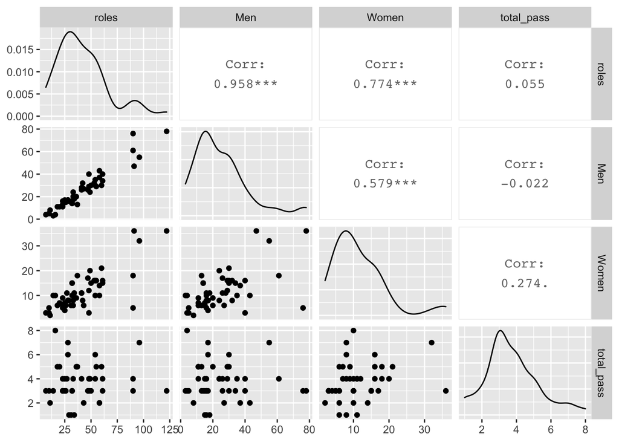

```r
corr<-corr[2:5] # this is another way of choosing the columns that we want, by # rather than name.

ggpairs(corr)
```

## Porportional Bar Chart  
Compare the number of films that failed and passed each test in a bar chart:

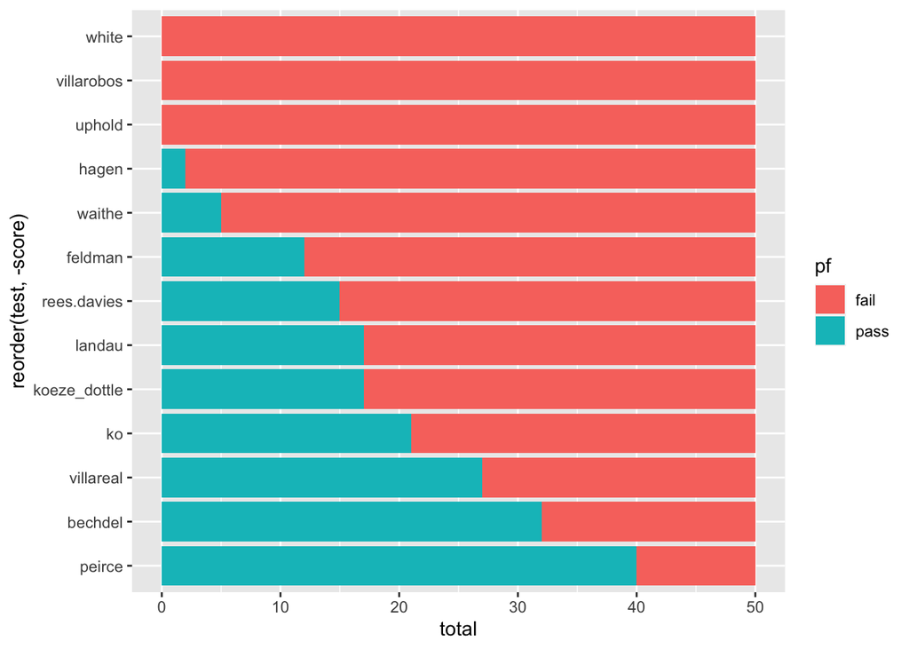

```r
# want to condense our all_tests data set so that test names are one column and pass/fail is another.
# we can do this easily using the gather function
# gather is basically the opposite of spread! It compresses columns into rows and makes our df much longer.

all_tests_long <- all_tests %>%
  gather(test, score,2:14) %>%
  mutate(pf=if_else(score==0, "fail", "pass"),total=1)

# now we'll make the plot without f

ggplot(all_tests_long, aes(y=reorder(test, -score), x=total, fill=pf))+
  geom_bar(stat="identity", position="stack")
```

```r
# reorder is a function that allows us to make neat graphs. What happens if we just set y=test?
```

ON YOUR OWN:

1. Make a bar chart that has a list of each film along the y-axis and then a stacked bar of the number of tests it fails and the number it passes. The code will look very similar to the bar chart above! Also, change the y-axis, x-axis, legend label with labs and add a title to the plot using ggtitle. Finally change the color scheme using scale fill manual.
2. Provide a correlation graph that looks at (1) the number of roles per film, (2) the number of women in a film, (3) the number of men in a film and (4) if it passes all the tests that are only concerned with what happens on camera (i.e. remove the uphold, rees.davies, and white tests from all_tests$total_pass. These are tests that concern the number of women crew & production members )